# DSC20 - Final Project

Sathish Manthani

11/12/2019

## Data import and cleansing

### Source dataset

[New York City Airbnb Open Data](https://www.kaggle.com/dgomonov/new-york-city-airbnb-open-data)

### Packages

Import the required packages/libraries to anlayze the dataset

```r
library(ggplot2)    # plots for visualization
library(dplyr)      # for data manipulation
library(corrplot)   # for display of correlation matrix
library(GGally)     # for gallary display of charts
library(gridExtra)  # to view plots in grid
library(purrr)      # for map_dbl function
```

### Read the data file

```r
airbnb.df  <- read.csv("AB_NYC_2019.csv", stringsAsFactors = FALSE)
```

### Understanding the data

```r
# view its class
class(airbnb.df)
```

```
## [1] "data.frame"
```

```r
# dimensions of the data
dim(airbnb.df)
```

```
## [1] 48895    16
```

```r
# Structure of the dataset
str(airbnb.df)
```

```
## 'data.frame':    48895 obs. of  16 variables:
##  $ id                            : int  2539 2595 3647 3831 5022 5099 5121 5178 5203 5238 ...
##  $ name                          : chr  "Clean & quiet apt home by the park" "Skylit Midtown Castle" "THE VILLAGE OF HARLEM....NEW YORK !" "Cozy Entire Floor of Brownstone" ...
##  $ host_id                       : int  2787 2845 4632 4869 7192 7322 7356 8967 7490 7549 ...
##  $ host_name                     : chr  "John" "Jennifer" "Elisabeth" "LisaRoxanne" ...
##  $ neighbourhood_group           : chr  "Brooklyn" "Manhattan" "Manhattan" "Brooklyn" ...
##  $ neighbourhood                 : chr  "Kensington" "Midtown" "Harlem" "Clinton Hill" ...
##  $ latitude                      : num  40.6 40.8 40.8 40.7 40.8 ...
##  $ longitude                     : num  -74 -74 -73.9 -74 -73.9 ...
##  $ room_type                     : chr  "Private room" "Entire home/apt" "Private room" "Entire home/apt" ...
##  $ price                         : int  149 225 150 89 80 200 60 79 79 150 ...
##  $ minimum_nights                : int  1 1 3 1 10 3 45 2 2 1 ...
##  $ number_of_reviews             : int  9 45 0 270 9 74 49 430 118 160 ...
##  $ last_review                   : chr  "2018-10-19" "2019-05-21" "" "2019-07-05" ...
##  $ reviews_per_month             : num  0.21 0.38 NA 4.64 0.1 0.59 0.4 3.47 0.99 1.33 ...
##  $ calculated_host_listings_count: int  6 2 1 1 1 1 1 1 1 4 ...
##  $ availability_365              : int  365 355 365 194 0 129 0 220 0 188 ...
```

There are no special characters or spaces in column names, renaming is not required.  
However, some of the categorical variables can be converted to factors. Before conversion, let’s check how many unique values are there for each of these variables in the dataset.

### Unique values of variables

```r
#following function gets unique values for each variable in the dataset
sapply(airbnb.df, function(x) length(unique(x)))
```

```
##                             id                           name
##                          48895                          47906
##                        host_id                      host_name
##                          37457                          11453
##            neighbourhood_group                  neighbourhood
##                              5                            221
##                       latitude                      longitude
##                          19048                          14718
##                      room_type                          price
##                              3                            674
##                 minimum_nights              number_of_reviews
##                            109                            394
##                    last_review              reviews_per_month
##                           1765                            938
## calculated_host_listings_count               availability_365
##                             47                            366
```

From the above output, I can see neighbourhood_group, room_type, neighbourhood variables can be factors

### Data type conversion

```r
# convert neighbourhood_group, room_type, neighbourhood to factors
airbnb.df['neighbourhood_group'] <- as.factor(airbnb.df$neighbourhood_group)
airbnb.df['room_type'] <- as.factor(airbnb.df$room_type)
airbnb.df['neighbourhood'] <- as.factor(airbnb.df$neighbourhood)

#Convert last_review to date datatype
airbnb.df['last_review'] <- as.Date(airbnb.df$'last_review')

#Look at the new structure
str(airbnb.df)
```

```
## 'data.frame':    48895 obs. of  16 variables:
##  $ id                            : int  2539 2595 3647 3831 5022 5099 5121 5178 5203 5238 ...
##  $ name                          : chr  "Clean & quiet apt home by the park" "Skylit Midtown Castle" "THE VILLAGE OF HARLEM....NEW YORK !" "Cozy Entire Floor of Brownstone" ...
##  $ host_id                       : int  2787 2845 4632 4869 7192 7322 7356 8967 7490 7549 ...
##  $ host_name                     : chr  "John" "Jennifer" "Elisabeth" "LisaRoxanne" ...
##  $ neighbourhood_group           : Factor w/ 5 levels "Bronx","Brooklyn",..: 2 3 3 2 3 3 2 3 3 3 ...
##  $ neighbourhood                 : Factor w/ 221 levels "Allerton","Arden Heights",..: 109 128 95 42 62 138 14 96 203 36 ...
##  $ latitude                      : num  40.6 40.8 40.8 40.7 40.8 ...
##  $ longitude                     : num  -74 -74 -73.9 -74 -73.9 ...
##  $ room_type                     : Factor w/ 3 levels "Entire home/apt",..: 2 1 2 1 1 1 2 2 2 1 ...
##  $ price                         : int  149 225 150 89 80 200 60 79 79 150 ...
##  $ minimum_nights                : int  1 1 3 1 10 3 45 2 2 1 ...
##  $ number_of_reviews             : int  9 45 0 270 9 74 49 430 118 160 ...
##  $ last_review                   : Date, format: "2018-10-19" "2019-05-21" ...
##  $ reviews_per_month             : num  0.21 0.38 NA 4.64 0.1 0.59 0.4 3.47 0.99 1.33 ...
##  $ calculated_host_listings_count: int  6 2 1 1 1 1 1 1 1 4 ...
##  $ availability_365              : int  365 355 365 194 0 129 0 220 0 188 ...
```

### Looking at the raw data

```r
head(airbnb.df)
```

|  | id | name | host_id | host_name | neighbourhood_group | neighbourhood | latitude | longitude | room_type | price | minimum_nights | number_of_reviews | last_review | reviews_per_month | calculated_host_listings_count | availability_365 |
| --- | --- | --- | --- | --- | --- | --- | --- | --- | --- | --- | --- | --- | --- | --- | --- | --- |
| 1 | 2539 | Clean & quiet apt home by the park | 2787 | John | Brooklyn | Kensington | 40.64749 | -73.97237 | Private room | 149 | 1 | 9 | 2018-10-19 | 0.21 | 6 | 365 |
| 2 | 2595 | Skylit Midtown Castle | 2845 | Jennifer | Manhattan | Midtown | 40.75362 | -73.98377 | Entire home/apt | 225 | 1 | 45 | 2019-05-21 | 0.38 | 2 | 355 |
| 3 | 3647 | THE VILLAGE OF HARLEM....NEW YORK ! | 4632 | Elisabeth | Manhattan | Harlem | 40.80902 | -73.94190 | Private room | 150 | 3 | 0 |  | NA | 1 | 365 |
| 4 | 3831 | Cozy Entire Floor of Brownstone | 4869 | LisaRoxanne | Brooklyn | Clinton Hill | 40.68514 | -73.95976 | Entire home/apt | 89 | 1 | 270 | 2019-07-05 | 4.64 | 1 | 194 |
| 5 | 5022 | Entire Apt: Spacious Studio/Loft by central park | 7192 | Laura | Manhattan | East Harlem | 40.79851 | -73.94399 | Entire home/apt | 80 | 10 | 9 | 2018-11-19 | 0.10 | 1 | 0 |
| 6 | 5099 | Large Cozy 1 BR Apartment In Midtown East | 7322 | Chris | Manhattan | Murray Hill | 40.74767 | -73.97500 | Entire home/apt | 200 | 3 | 74 | 2019-06-22 | 0.59 | 1 | 129 |

### Drop unwanted variables

As we can see there are a couple of id columns namely id, host_id which dont carry much information as far as our analysis is concerned. So I’m removing them from the dataset.

```r
drops <- c("id","host_id")
airbnb.df <- airbnb.df[ , !(names(airbnb.df) %in% drops)]
```

Check if there are any **duplicate rows** from the dataset. Duplicate rows can affect the data analysis.

### Duplicate check

```r
#Number of observations in the file
rows <- nrow(airbnb.df)

#Number of unique rows
unique_rows <- nrow(unique(airbnb.df))

rows == unique_rows
```

```
## [1] TRUE
```

Since the total rows is equal to unique rows, we can see that there are no duplicates in the dataset.

### Missing values

Check for missing values in the dataset. Missing values can lead to unwanted results, so its good to cleanse such rows.

```r
sapply(airbnb.df,      # apply to each column of the dataframe
  function(x)  # this function:
    sum(is.na(x))  # count the NAs
) / nrow(airbnb.df) * 100  # then divide the result by the number of rows in the airbnb dataframe
```

```
##                           name                      host_name
##                        0.00000                        0.00000
##            neighbourhood_group                  neighbourhood
##                        0.00000                        0.00000
##                       latitude                      longitude
##                        0.00000                        0.00000
##                      room_type                          price
##                        0.00000                        0.00000
##                 minimum_nights              number_of_reviews
##                        0.00000                        0.00000
##                    last_review              reviews_per_month
##                       20.55834                       20.55834
## calculated_host_listings_count               availability_365
##                        0.00000                        0.00000
```

```r
#summary(airbnb.df)
airbnb.df[is.na(airbnb.df$price)]
```

From the above output, we can see reviews_per_month variable has 20% NA values.  
I’ll omit the missing value rows if I find reviews_per_month has significant effect on the price of the hotel.  
For now, I think there’s no need to manually treat the data.

## Understand categorical variables

```r
#Neighbourhood Groups
levels(airbnb.df$neighbourhood_group)
```

```
## [1] "Bronx"         "Brooklyn"      "Manhattan"     "Queens"
## [5] "Staten Island"
```

```r
#Available room types
levels(airbnb.df$room_type)
```

```
## [1] "Entire home/apt" "Private room"    "Shared room"
```

```r
#Glimpse of Airbnb dataset
glimpse(airbnb.df)
```

```
## Observations: 48,895
## Variables: 14
## $ name                           <chr> "Clean & quiet apt home by the pa…
## $ host_name                      <chr> "John", "Jennifer", "Elisabeth", …
## $ neighbourhood_group            <fct> Brooklyn, Manhattan, Manhattan, B…
## $ neighbourhood                  <fct> Kensington, Midtown, Harlem, Clin…
## $ latitude                       <dbl> 40.64749, 40.75362, 40.80902, 40.…
## $ longitude                      <dbl> -73.97237, -73.98377, -73.94190, …
## $ room_type                      <fct> Private room, Entire home/apt, Pr…
## $ price                          <int> 149, 225, 150, 89, 80, 200, 60, 7…
## $ minimum_nights                 <int> 1, 1, 3, 1, 10, 3, 45, 2, 2, 1, 5…
## $ number_of_reviews              <int> 9, 45, 0, 270, 9, 74, 49, 430, 11…
## $ last_review                    <date> 2018-10-19, 2019-05-21, NA, 2019…
## $ reviews_per_month              <dbl> 0.21, 0.38, NA, 4.64, 0.10, 0.59,…
## $ calculated_host_listings_count <int> 6, 2, 1, 1, 1, 1, 1, 1, 1, 4, 1, …
## $ availability_365               <int> 365, 355, 365, 194, 0, 129, 0, 22…
```

## Question A

*Discuss how you plan to uncover new information in the data that is not self-evident.*

### Distributions

Let’s take a look at the distribution of our target variable “Price” -

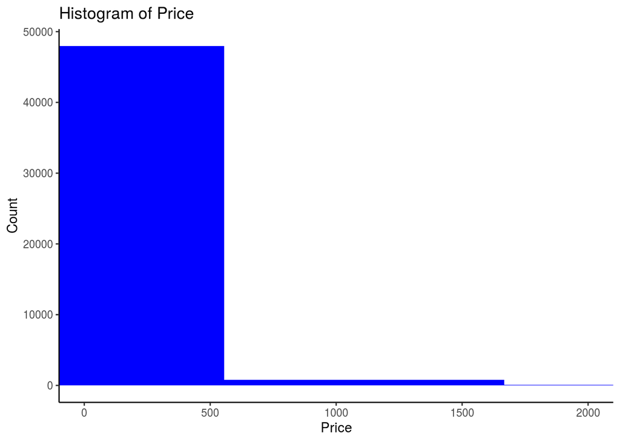

```r
#Distribution of Price variable
ggplot(airbnb.df, aes(x=price)) + geom_histogram(bins = 10, fill = 'blue') + coord_cartesian(xlim=c(0,2000)) + theme_classic() + labs(title = 'Histogram of Price', x = 'Price', y = 'Count')
```

It doesn’t look like a Normal distribution. It is heavily skewed to the right.

### Histogram of Price with LOG transformation

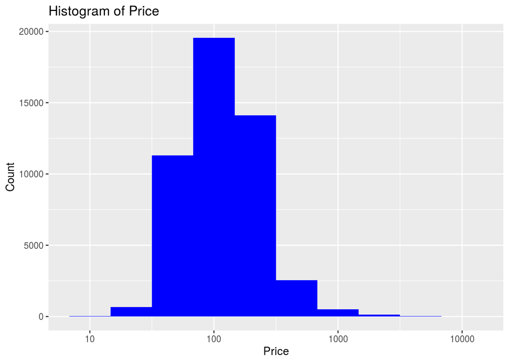

```r
#Distribution of Price variable
ggplot(airbnb.df, aes(x=price) ) + geom_histogram(bins = 10, fill = 'blue') + scale_x_log10() + labs(title = 'Histogram of Price', x = 'Price', y = 'Count')
```

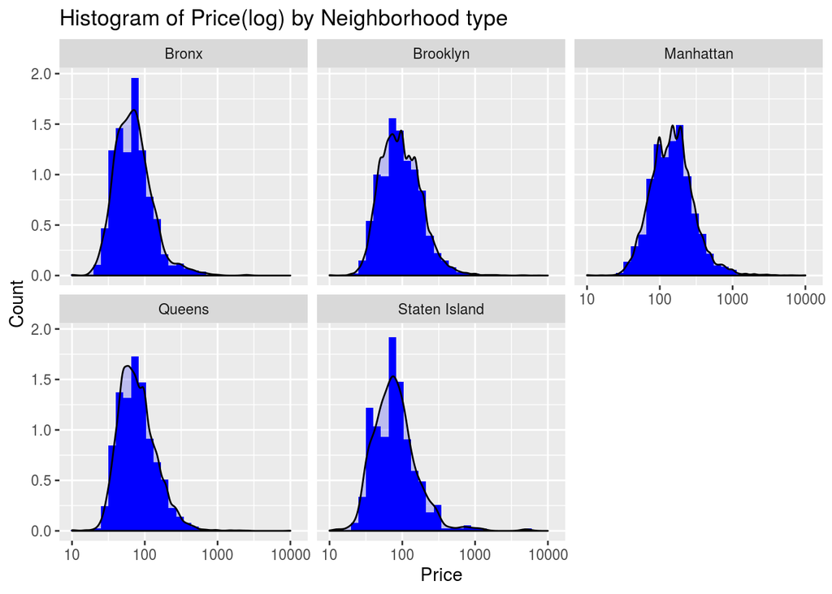

```r
 ggplot(airbnb.df, aes(x=price) ) + geom_histogram(bins = 30, aes(y = ..density..), fill = "blue") +   geom_density(alpha = 0.2, fill = "blue") + scale_x_log10() + labs(title = 'Histogram of Price(log) by Neighborhood type ', x = 'Price', y = 'Count')+ facet_wrap(~neighbourhood_group)
```

### Correlation

I want to check the correlation between Price and Number of reviews, Minimum nights and Availability_365 variables

```r
# Reading numberic variables and checking for correlation
df  <- airbnb.df  %>% select("price","number_of_reviews","minimum_nights", "availability_365")
cor(df)
```

```
##                         price number_of_reviews minimum_nights
## price              1.00000000       -0.04795423     0.04279933
## number_of_reviews -0.04795423        1.00000000    -0.08011607
## minimum_nights     0.04279933       -0.08011607     1.00000000
## availability_365   0.08182883        0.17202758     0.14430306
##                   availability_365
## price                   0.08182883
## number_of_reviews       0.17202758
## minimum_nights          0.14430306
## availability_365        1.00000000
```

These variables are not highly linearly correlated(values < 0.1) to Price variable.

```r
#Quantiles of price
summary(airbnb.df$price)
```

```
##    Min. 1st Qu.  Median    Mean 3rd Qu.    Max.
##     0.0    69.0   106.0   152.7   175.0 10000.0
```

Median Airbnb rental price is $106 in NYC and Max price being $10k.

## Question B

*What are different ways you could look at this data to answer the questions you want to answer?*

We can look at this data using different visual plots to understand it first. For e.g. Price by Room type using boxplot.  
Or Price by Neighbourhood Group using boxplot, Price distribution.  
How number of reviews is related to Price.  
How room availability is related to Price.

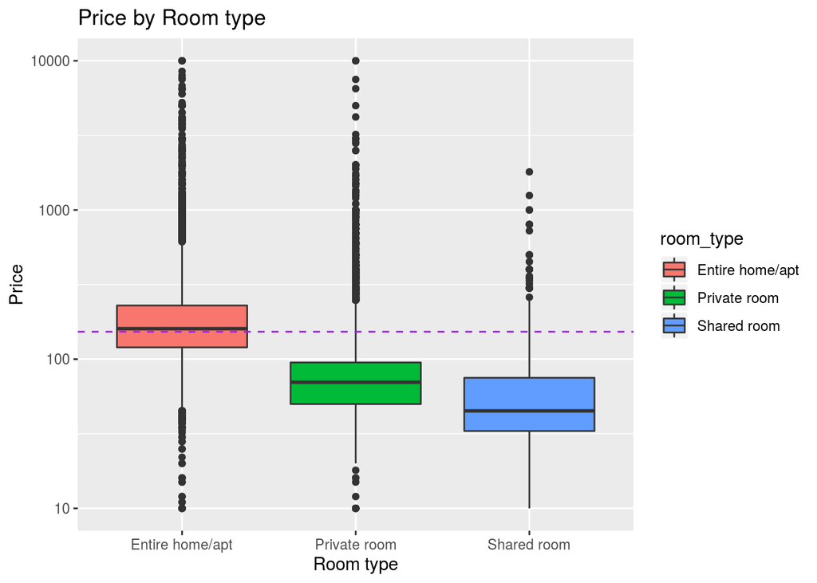

```r
#Room type vs Price plot
ggplot(airbnb.df, aes(x = room_type, y = price)) +
  geom_boxplot(aes(fill = room_type)) + scale_y_log10() +
  labs(title = 'Price by Room type', x = 'Room type', y = 'Price') + geom_hline(yintercept = mean(airbnb.df$price), color = "purple", linetype = 2)
```

From the above plot, we can see Home/Apt’s mean price is higher than other room types.  
So, room type is definitely related to Price variable.

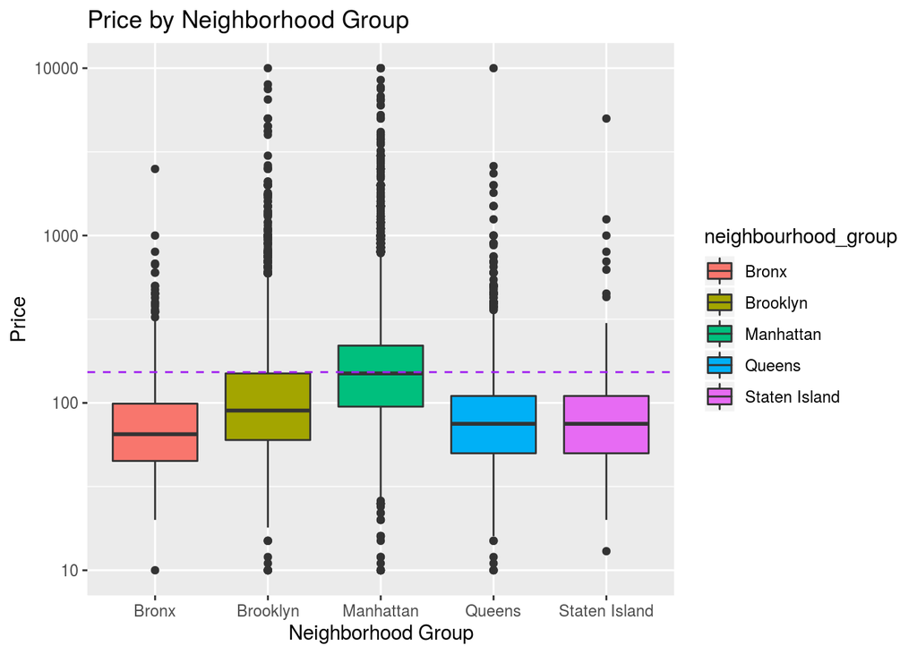

```r
# Neighborhood group vs Price plot
ggplot(airbnb.df, aes(x = neighbourhood_group, y = price)) +
  geom_boxplot(aes(fill = neighbourhood_group)) + scale_y_log10() +
  labs(title = 'Price by Neighborhood Group', x = 'Neighborhood Group', y = 'Price') + geom_hline(yintercept = mean(airbnb.df$price), color = "purple", linetype = 2)
```

From the above plot, we can see Airbnb hotels are expensive in Manhattan and Bronx being the cheapest!  
So, Neighborhood Group has relationship with Price.

## Question C

*Do you plan to slice and dice the data in different ways, create new variables, or join separate data frames to create new summary information? Explain.*

Yes, like I said in the previous question - I would like to see Price using different dimensions like Room type, Neighbourhood, Number of reviews and Availability.  
New variables and joining dataframes maynot be needed for my analysis.

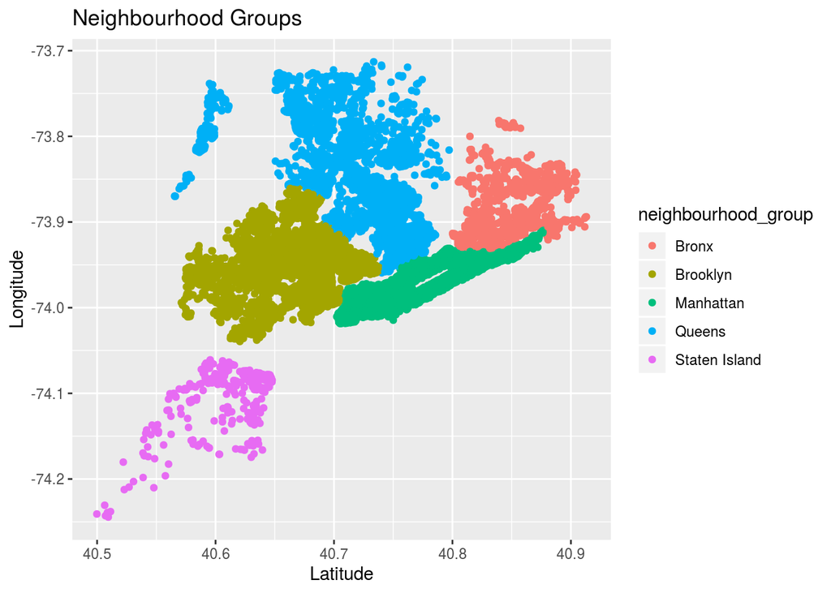

```r
#Neighbourhood group with latitude and logitude
ggplot(data = airbnb.df, aes(latitude, longitude, color = neighbourhood_group)) + geom_point() + labs(title = "Neighbourhood Groups", x = "Latitude", y = "Longitude")
```

The above map shows the neighbourhood group map and appropriately colors it.

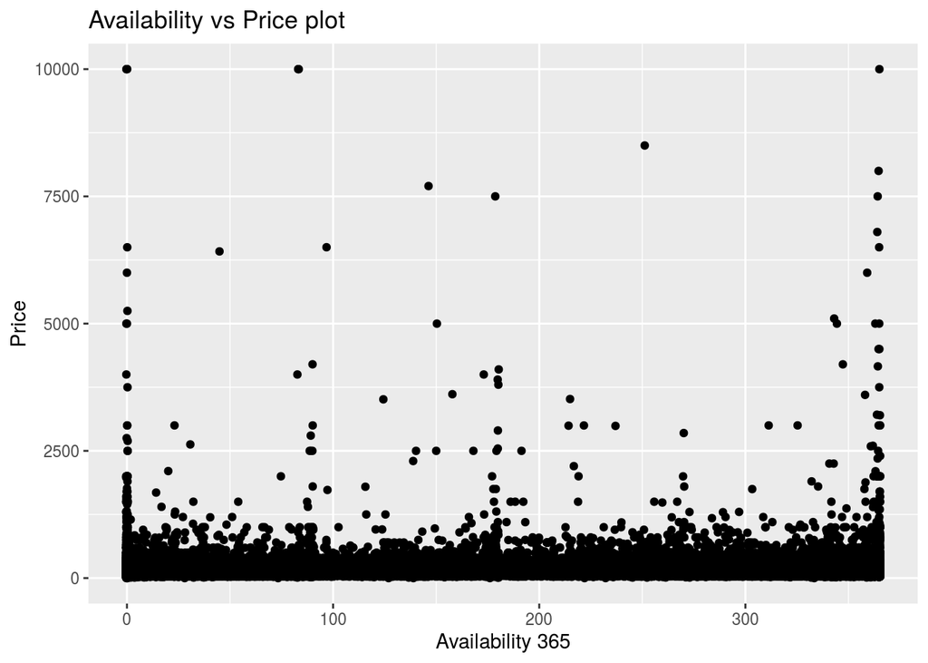

```r
#Availability vs Price plot
ggplot(airbnb.df, aes(availability_365, price)) + geom_jitter() + labs(title = 'Availability vs Price plot', x = 'Availability 365', y = 'Price')
```

There is no particular linear correlation between Price vs Availability variable alone.

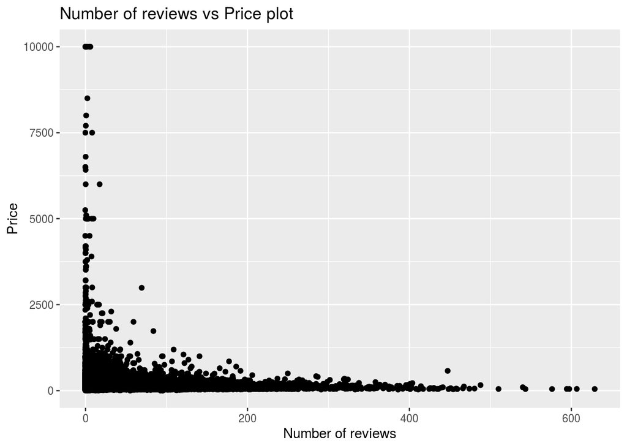

```r
#Number of reviews vs Price plot
ggplot(airbnb.df, aes(number_of_reviews, price)) + geom_jitter() + labs(title = 'Number of reviews vs Price plot', x = 'Number of reviews', y = 'Price')
```

```r
##Price values are most occuring in the dataset
top_10 <- airbnb.df  %>%  select(price)  %>% group_by(price)  %>% summarise(count = n())  %>%
arrange(desc(count)) %>% top_n(10)
top_10
```

| price | count |
| --- | --- |
| 100 | 2051 |
| 150 | 2047 |
| 50 | 1534 |
| 60 | 1458 |
| 200 | 1401 |
| 75 | 1370 |
| 80 | 1272 |
| 65 | 1190 |
| 70 | 1170 |
| 120 | 1130 |

From the above aggregate counts, the most used Price value in the dataset is 100. So, no wonder the median is 106.

## Linear regression

```r
# linear regression model for Price
price_model1 = lm(price ~ latitude + longitude + room_type + minimum_nights  + availability_365 + neighbourhood_group, data = airbnb.df)
summary(price_model1) #Review the results
```

```
##
## Call:
## lm(formula = price ~ latitude + longitude + room_type + minimum_nights +
##     availability_365 + neighbourhood_group, data = airbnb.df)
##
## Residuals:
##    Min     1Q Median     3Q    Max
## -244.3  -62.2  -24.7   14.8 9946.1
##
## Coefficients:
##                                    Estimate Std. Error t value Pr(>|t|)
## (Intercept)                      -2.915e+04  3.210e+03  -9.083  < 2e-16
## latitude                         -1.979e+02  3.132e+01  -6.320 2.64e-10
## longitude                        -5.058e+02  3.597e+01 -14.062  < 2e-16
## room_typePrivate room            -1.052e+02  2.160e+00 -48.707  < 2e-16
## room_typeShared room             -1.380e+02  6.886e+00 -20.040  < 2e-16
## minimum_nights                    1.210e-02  5.123e-02   0.236 0.813216
## availability_365                  1.653e-01  8.078e-03  20.460  < 2e-16
## neighbourhood_groupBrooklyn      -3.293e+01  8.773e+00  -3.753 0.000175
## neighbourhood_groupManhattan      2.756e+01  7.967e+00   3.459 0.000542
## neighbourhood_groupQueens        -4.651e+00  8.459e+00  -0.550 0.582398
## neighbourhood_groupStaten Island -1.514e+02  1.668e+01  -9.077  < 2e-16
##
## (Intercept)                      ***
## latitude                         ***
## longitude                        ***
## room_typePrivate room            ***
## room_typeShared room             ***
## minimum_nights
## availability_365                 ***
## neighbourhood_groupBrooklyn      ***
## neighbourhood_groupManhattan     ***
## neighbourhood_groupQueens
## neighbourhood_groupStaten Island ***
## ---
## Signif. codes:  0 '***' 0.001 '**' 0.01 '*' 0.05 '.' 0.1 ' ' 1
##
## Residual standard error: 228.5 on 48884 degrees of freedom
## Multiple R-squared:  0.09488,    Adjusted R-squared:  0.09469
## F-statistic: 512.4 on 10 and 48884 DF,  p-value: < 2.2e-16
```

Linear regression for target variable Price with independent variables latitude, longitude, room_type, minimum_nights , availability_365 and neighbourhood_group.

The model can be viewed visually below.

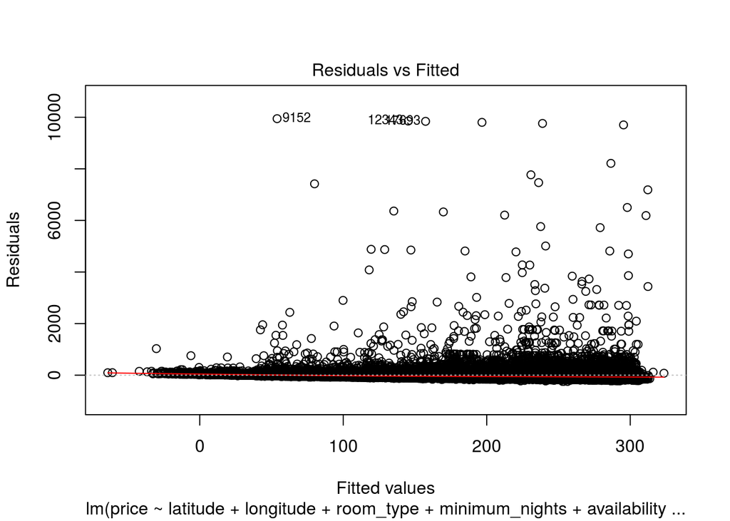

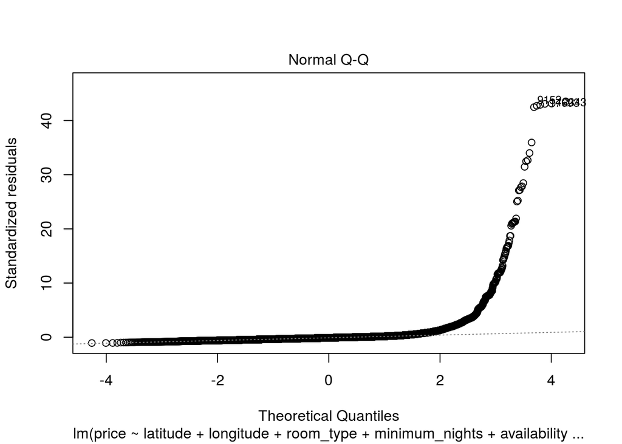

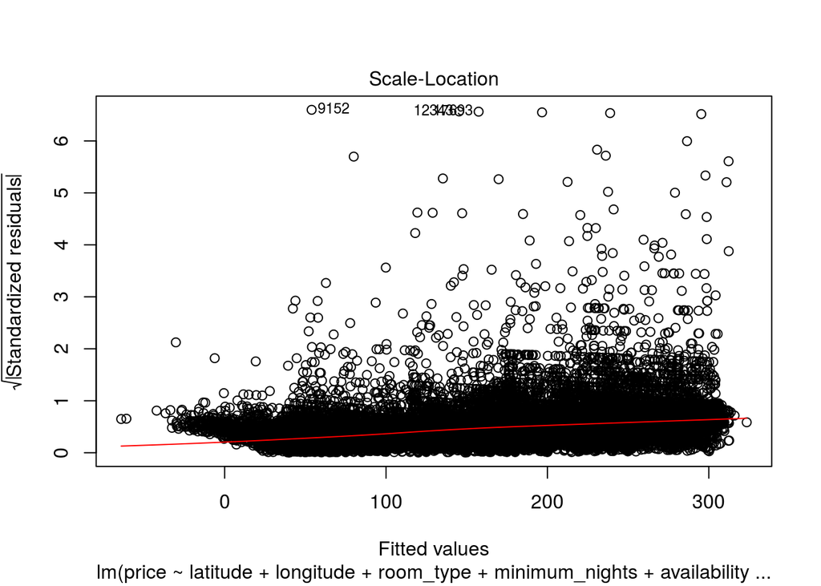

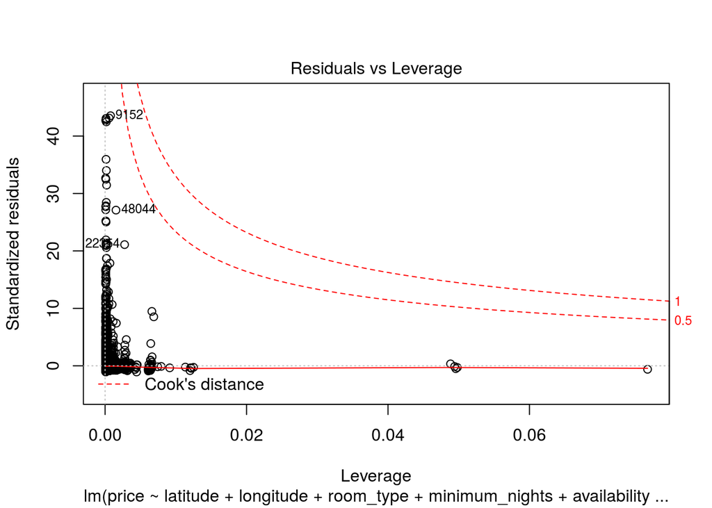

```r
plot(price_model1)
```

Normal Q-Q plot tells us that the model is not a great fit.  
Outliers causing leverage to be high on certain points.

```r
airbnb.df$log_price <- log(airbnb.df$price + min(airbnb.df$price) + 1)
#training.df$log_price <- log(training.df$price + min(training.df$price) + 1)
#testing.df$log_price <- log(testing.df$price + min(testing.df$price) + 1)


#all(is.na(log(airbnb.df$price)))
# linear regression model for Price
price_model2 = lm(log_price ~ latitude + longitude + room_type + minimum_nights  + availability_365 + neighbourhood_group, data = airbnb.df, na.action=na.exclude)
summary(price_model2) #Review the results
```

```
##
## Call:
## lm(formula = log_price ~ latitude + longitude + room_type + minimum_nights +
##     availability_365 + neighbourhood_group, data = airbnb.df,
##     na.action = na.exclude)
##
## Residuals:
##     Min      1Q  Median      3Q     Max
## -5.2528 -0.3115 -0.0537  0.2347  5.2433
##
## Coefficients:
##                                    Estimate Std. Error  t value Pr(>|t|)
## (Intercept)                      -1.935e+02  7.005e+00  -27.625  < 2e-16
## latitude                         -6.368e-01  6.836e-02   -9.315  < 2e-16
## longitude                        -3.034e+00  7.850e-02  -38.654  < 2e-16
## room_typePrivate room            -7.467e-01  4.714e-03 -158.406  < 2e-16
## room_typeShared room             -1.143e+00  1.503e-02  -76.084  < 2e-16
## minimum_nights                   -1.742e-03  1.118e-04  -15.576  < 2e-16
## availability_365                  6.964e-04  1.763e-05   39.502  < 2e-16
## neighbourhood_groupBrooklyn      -4.707e-02  1.915e-02   -2.459    0.014
## neighbourhood_groupManhattan      2.604e-01  1.739e-02   14.974  < 2e-16
## neighbourhood_groupQueens         8.166e-02  1.846e-02    4.423 9.75e-06
## neighbourhood_groupStaten Island -8.208e-01  3.641e-02  -22.545  < 2e-16
##
## (Intercept)                      ***
## latitude                         ***
## longitude                        ***
## room_typePrivate room            ***
## room_typeShared room             ***
## minimum_nights                   ***
## availability_365                 ***
## neighbourhood_groupBrooklyn      *
## neighbourhood_groupManhattan     ***
## neighbourhood_groupQueens        ***
## neighbourhood_groupStaten Island ***
## ---
## Signif. codes:  0 '***' 0.001 '**' 0.01 '*' 0.05 '.' 0.1 ' ' 1
##
## Residual standard error: 0.4987 on 48884 degrees of freedom
## Multiple R-squared:  0.4857, Adjusted R-squared:  0.4856
## F-statistic:  4617 on 10 and 48884 DF,  p-value: < 2.2e-16
```

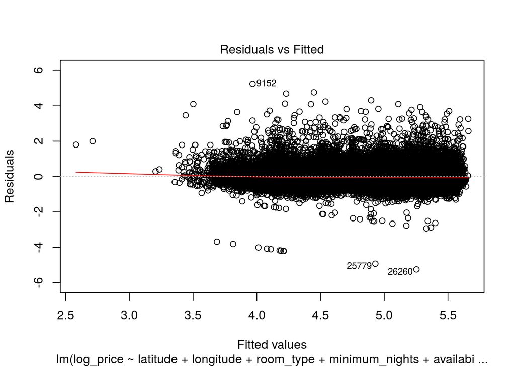

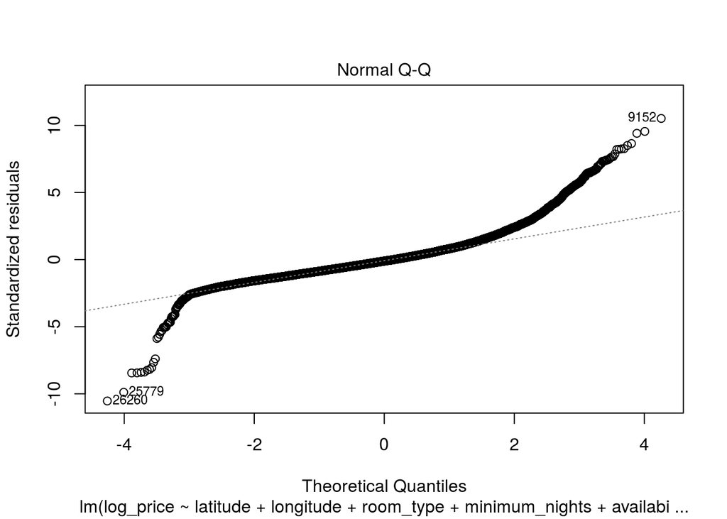

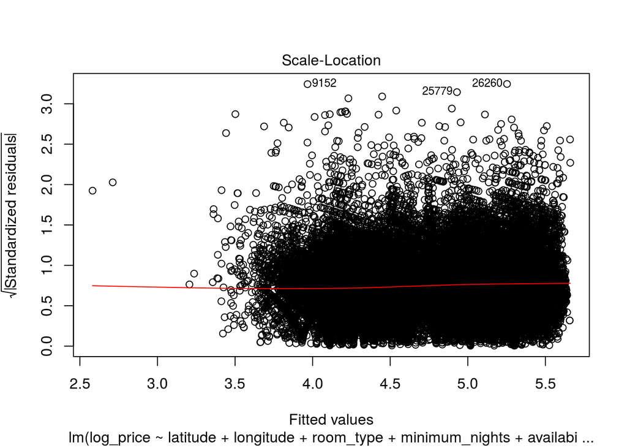

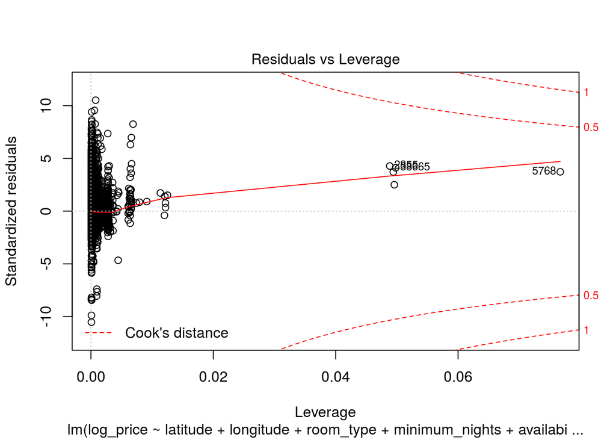

```r
plot(price_model2)
```